# CreditCard_Predict_v1

Arup Ghosh

2/20/2021

# A Probabilistic Graphical Model (PGM)

# Problem statement: Who gets Platinum Credit Card?

Demographic predictors

- Age (A): **ADULT** for individuals between 30 and 60 years old; and **MATURE** for people older than 60.

Socioeconomic indicators

- Education level (E): the highest level of education completed by the individual: Doctorate,Post Graduate,Graduate (**HIGH**), High School,uneducated (**LOW**).
- Income Category (I): more than 60K (**HIGH**) or less than 60K (**LOW**)
- Marital Status (M): **MARRIED** or **SINGLE**

Prediction target

- Credit Card type (C): **SILVER**, **GOLD**, or **PLATINUM**

## Read the dataset-Data Aalysis

```r
credit_card.df <- read.csv("Data/credit_card/BankChurners.csv")
class(credit_card.df)
```

```
## [1] "data.frame"
```

```r
names(credit_card.df)
```

```
## [1] "A" "E" "M" "I" "C"
```

```r
dim(credit_card.df)
```

```
## [1] 10127     5
```

```r
str(credit_card.df)
```

```
## 'data.frame':    10127 obs. of  5 variables:
##  $ A: chr  "ADULT" "ADULT" "ADULT" "ADULT" ...
##  $ E: chr  "LOW" "HIGH" "HIGH" "LOW" ...
##  $ M: chr  "Married" "Single" "Married" "Single" ...
##  $ I: chr  "HIGH" "LOW" "HIGH" "LOW" ...
##  $ C: chr  "Silver" "Silver" "Silver" "Silver" ...
```

```r
summary(credit_card.df)
```

```
##       A                  E                  M                  I
##  Length:10127       Length:10127       Length:10127       Length:10127
##  Class :character   Class :character   Class :character   Class :character
##  Mode  :character   Mode  :character   Mode  :character   Mode  :character
##       C
##  Length:10127
##  Class :character
##  Mode  :character
```

# Boxplots

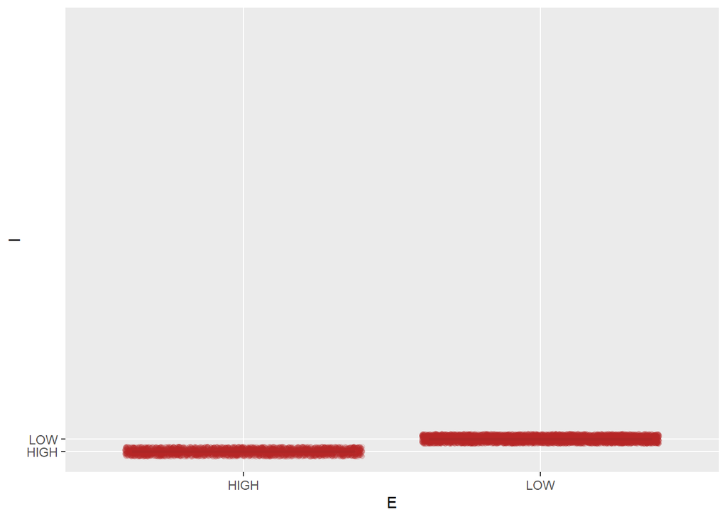

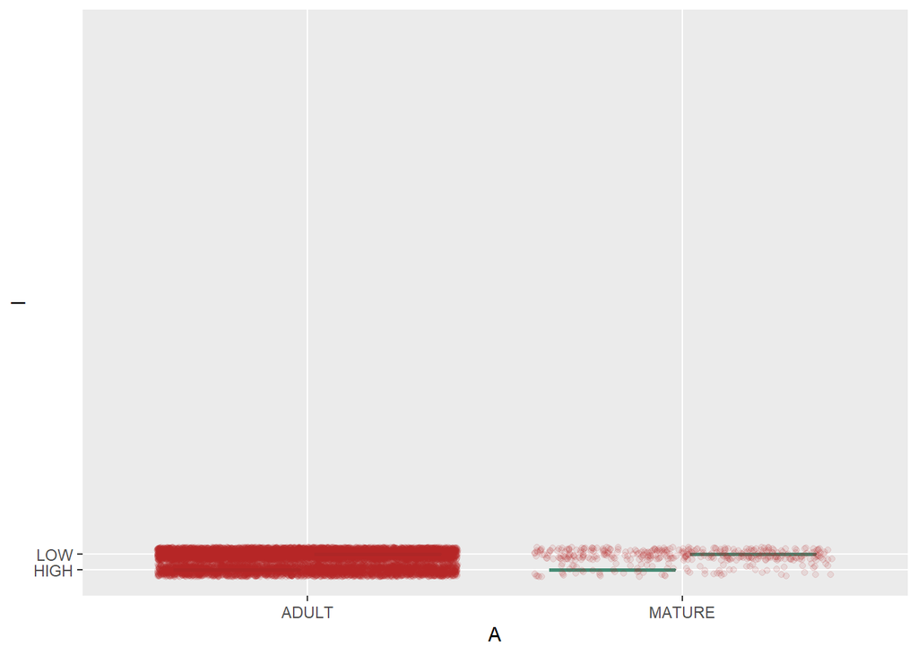

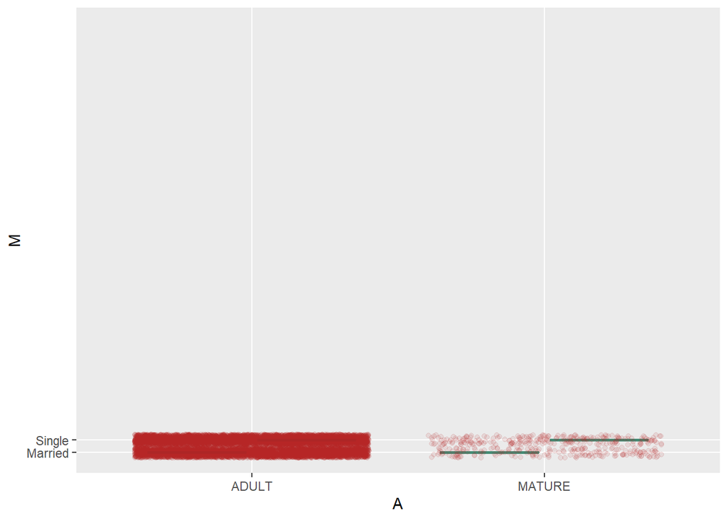

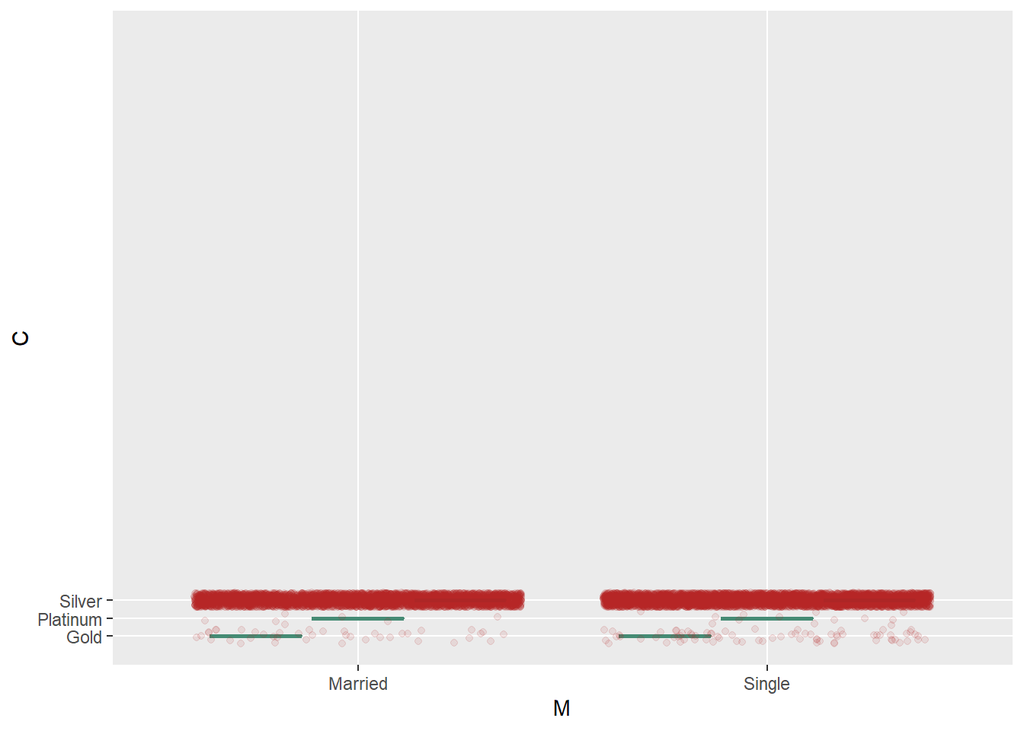

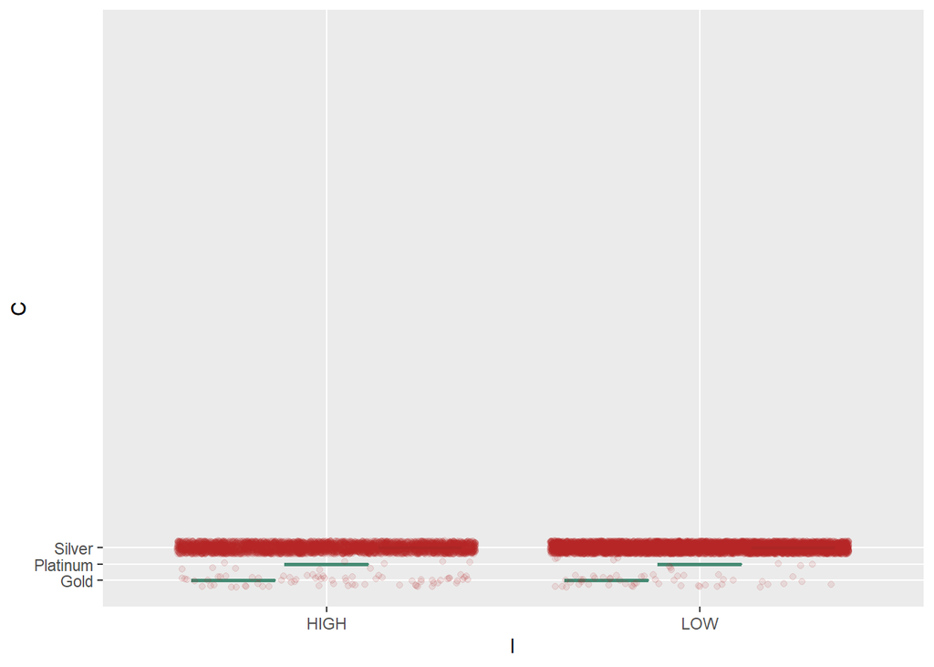

## Define the Bayesian network

```r
dag <- empty.graph(nodes = c("A", "E", "I", "M", "C"))
```

```r
dag
```

```
##
##   Random/Generated Bayesian network
##
##   model:
##    [A][E][I][M][C]
##   nodes:                                 5
##   arcs:                                  0
##     undirected arcs:                     0
##     directed arcs:                       0
##   average markov blanket size:           0.00
##   average neighbourhood size:            0.00
##   average branching factor:              0.00
##
##   generation algorithm:                  Empty
```

```r
dag <- set.arc(dag, from = "E", to = "I")
dag <- set.arc(dag, from = "A", to = "I")
dag <- set.arc(dag, from = "A", to = "M")
dag <- set.arc(dag, from = "I", to = "C")
dag <- set.arc(dag, from = "M", to = "C")
```

```r
dag
```

```
##
##   Random/Generated Bayesian network
##
##   model:
##    [A][E][I|A:E][M|A][C|I:M]
##   nodes:                                 5
##   arcs:                                  5
##     undirected arcs:                     0
##     directed arcs:                       5
##   average markov blanket size:           2.80
##   average neighbourhood size:            2.00
##   average branching factor:              1.00
##
##   generation algorithm:                  Empty
```

# Exploring the bn object

```r
nodes(dag)
```

```
## [1] "A" "E" "I" "M" "C"
```

```r
arcs(dag)
```

```
##      from to
## [1,] "E"  "I"
## [2,] "A"  "I"
## [3,] "A"  "M"
## [4,] "I"  "C"
## [5,] "M"  "C"
```

# Joint probability as a product of conditional probabilitiies

Use the `modelstring` function to generate the product of conditional probabilities.

```r
modelstring(dag)
```

```
## [1] "[A][E][I|A:E][M|A][C|I:M]"
```

# Specify joint probability distribution over the random variables

```r
A.lv <- c("ADULT", "MATURE") # age
E.lv <- c("HIGH", "LOW") # education category
I.lv <- c("HIGH", "LOW") # income category
M.lv <- c("Married", "Single") # marital status
C.lv <- c("Silver", "Gold","Platinum") # card type
```

#Marginal probability distributions for Education variables

```r
E.prob <- array(c(.40,.60),dim=2,dimnames = list(E = E.lv))
E.prob
```

```
## E
## HIGH  LOW
##  0.4  0.6
```

#Marginal probability distributions for Age variables

```r
A.prob <- array(c(.40,.60),dim=2,dimnames = list(A = A.lv))
A.prob
```

```
## A
##  ADULT MATURE
##    0.4    0.6
```

#Conditional Probability Tables (CPTs) for Income Category variable are modeled using three-dimensional tables:

```r
I.prob <- array(c(.35,.65,.37,.63,.2,.8,.15,.85), dim = c(2, 2, 2),
            dimnames = list(I = I.lv, E = E.lv, A = A.lv))
I.prob
```

```
## , , A = ADULT
##
##       E
## I      HIGH  LOW
##   HIGH 0.35 0.37
##   LOW  0.65 0.63
##
## , , A = MATURE
##
##       E
## I      HIGH  LOW
##   HIGH  0.2 0.15
##   LOW   0.8 0.85
```

#Conditional probability distributions for Marital Status variables:

```r
M.prob <- array(c(.46,.54,.45,.55), dim = c(2, 2),
            dimnames = list(M = M.lv, A = A.lv))
M.prob
```

```
##          A
## M         ADULT MATURE
##   Married  0.46   0.45
##   Single   0.54   0.55
```

#Conditional Probability Tables (CPTs) for Credit Card Type variable are modeled using three-dimensional tables:

```r
C.prob <- array(c(.98,.01,.01,.98,.01,.01,.97,.02,.01,.98,.01,.01), dim = c(3, 2, 2),
            dimnames = list(C = C.lv, I = I.lv, M = M.lv))
C.prob
```

```
## , , M = Married
##
##           I
## C          HIGH  LOW
##   Silver   0.98 0.98
##   Gold     0.01 0.01
##   Platinum 0.01 0.01
##
## , , M = Single
##
##           I
## C          HIGH  LOW
##   Silver   0.97 0.98
##   Gold     0.02 0.01
##   Platinum 0.01 0.01
```

# We can combine our DAG defined earlier with CPTs to create an object of the bn.fit class:

```r
cpt <- list(A = A.prob, E = E.prob, I = I.prob, M = M.prob,
        C = C.prob)

bn <- custom.fit(dag, cpt)
```

#Number of parameters of the model:

```r
nparams(bn)
```

```
## [1] 16
```

#Number of edges in the model:

```r
arcs(bn)
```

```
##      from to
## [1,] "A"  "I"
## [2,] "A"  "M"
## [3,] "E"  "I"
## [4,] "I"  "C"
## [5,] "M"  "C"
```

#Print all CPTs in the model:

```r
bn
```

```
##
##   Bayesian network parameters
##
##   Parameters of node A (multinomial distribution)
##
## Conditional probability table:
##  A
##  ADULT MATURE
##    0.4    0.6
##
##   Parameters of node E (multinomial distribution)
##
## Conditional probability table:
##  E
## HIGH  LOW
##  0.4  0.6
##
##   Parameters of node I (multinomial distribution)
##
## Conditional probability table:
##
## , , E = HIGH
##
##       A
## I      ADULT MATURE
##   HIGH  0.35   0.20
##   LOW   0.65   0.80
##
## , , E = LOW
##
##       A
## I      ADULT MATURE
##   HIGH  0.37   0.15
##   LOW   0.63   0.85
##
##
##   Parameters of node M (multinomial distribution)
##
## Conditional probability table:
##
```

[output cut: 9 more lines]

```
## , , M = Married
##
##           I
## C          HIGH  LOW
##   Silver   0.98 0.98
##   Gold     0.01 0.01
##   Platinum 0.01 0.01
##
## , , M = Single
##
##           I
## C          HIGH  LOW
##   Silver   0.97 0.98
##   Gold     0.02 0.01
##   Platinum 0.01 0.01
```

# Estimating the model parameters from an observed sample

```r
survey <- read.table("data/credit_card/BankChurners.csv", header = TRUE,sep=",")
```

```r
class(survey)
```

```
## [1] "data.frame"
```

```r
str(survey)
```

```
## 'data.frame':    10127 obs. of  5 variables:
##  $ A: chr  "ADULT" "ADULT" "ADULT" "ADULT" ...
##  $ E: chr  "LOW" "HIGH" "HIGH" "LOW" ...
##  $ M: chr  "Married" "Single" "Married" "Single" ...
##  $ I: chr  "HIGH" "LOW" "HIGH" "LOW" ...
##  $ C: chr  "Silver" "Silver" "Silver" "Silver" ...
```

```r
names(survey)
```

```
## [1] "A" "E" "M" "I" "C"
```

```r
class(survey$A)
```

```
## [1] "character"
```

```r
survey[] <- lapply( survey, factor)
```

```r
str(survey)
```

```
## 'data.frame':    10127 obs. of  5 variables:
##  $ A: Factor w/ 2 levels "ADULT","MATURE": 1 1 1 1 1 1 1 1 1 1 ...
##  $ E: Factor w/ 2 levels "HIGH","LOW": 2 1 1 2 2 1 2 2 2 1 ...
##  $ M: Factor w/ 2 levels "Married","Single": 1 2 1 2 1 1 1 2 2 2 ...
##  $ I: Factor w/ 2 levels "HIGH","LOW": 1 2 1 2 1 2 1 1 1 1 ...
##  $ C: Factor w/ 3 levels "Gold","Platinum",..: 3 3 3 3 3 3 1 3 3 3 ...
```

```r
class(survey$A)
```

```
## [1] "factor"
```

```r
head(survey)
```

```
##       A    E       M    I      C
## 1 ADULT  LOW Married HIGH Silver
## 2 ADULT HIGH  Single  LOW Silver
## 3 ADULT HIGH Married HIGH Silver
## 4 ADULT  LOW  Single  LOW Silver
## 5 ADULT  LOW Married HIGH Silver
## 6 ADULT HIGH Married  LOW Silver
```

# Training Data and Test Data split

```r
dt = sort(sample(nrow(survey), nrow(survey)*.7))
train<-survey[dt,]
test<-survey[-dt,]
```

#In **bnlearn**, we compute MLE using the **bn.fit** function.

```r
options(digits = 3)
bn.mle <- bn.fit(dag, data = train, method = "mle")

bn.bayes <- bn.fit(dag, data = train, method = "bayes",
              iss = 10)
bn.bayes$M
```

```
##
##   Parameters of node M (multinomial distribution)
##
## Conditional probability table:
##
##          A
## M         ADULT MATURE
##   Married 0.460  0.437
##   Single  0.540  0.563
```

```r
bn.bayes <- bn.fit(dag, data = train, method = "bayes",
              iss = 30)
bn.bayes$M
```

```
##
##   Parameters of node M (multinomial distribution)
##
## Conditional probability table:
##
##          A
## M         ADULT MATURE
##   Married 0.460  0.439
##   Single  0.540  0.561
```

#Network scores

```r
set.seed(456)
options(digits = 6)
score(dag, data = train, type = "bic")
```

```
## [1] -16103.4
```

```r
score(dag, data = test, type = "bic")
```

```
## [1] -6902.46
```

```r
rnd <- random.graph(nodes = c("E", "A", "I", "M", "C"))
modelstring(rnd)
```

```
## [1] "[E][A|E][I|E][M|A:I][C|A:I:M]"
```

```r
score(rnd, data = train, type = "bic")
```

```
## [1] -16159.2
```

```r
score(rnd, data = test, type = "bic")
```

```
## [1] -6944.76
```

```r
learned <- hc(train)
modelstring(learned)
```

```
## [1] "[A][E][M][I|A][C|I]"
```

```r
learned2 <- hc(train, score = "bde")
options(digits=3)
arc.strength(learned, data = train, criterion = "bic")
```

```
##   from to strength
## 1    A  I   -18.64
## 2    I  C    -2.11
```

```r
arc.strength(dag, data = train, criterion = "bic")
```

```
##   from to strength
## 1    E  I     6.68
## 2    A  I   -14.43
## 3    A  M     4.11
## 4    I  C     3.13
## 5    M  C    10.56
```

#Plot the model

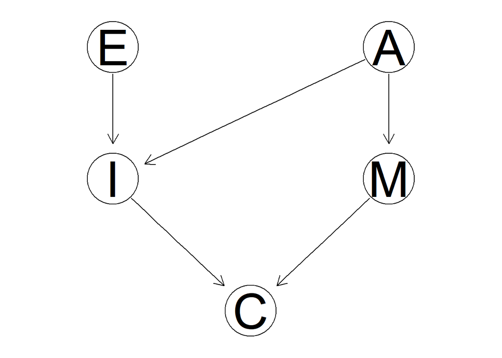

```r
graphviz.plot(dag)
```